# Untitled

Carmen

2025-11-17

```r
library(data.table)
library(dplyr)
```

```r
library(ggplot2)
library(lubridate)
library(scales)
```

```r
load("C:/Users/carme/Downloads/Modulo_8_proyecto/output/output/datos_minimos_accidentes_limpio.RData")
dt <- as.data.table(datos_minimos_accidentes_limpio)
```

```r
dt[, fatal := ifelse(estado_de_la_victima == "Fallecido", 1, 0)]
```

```r
# 3.1 Grupo de edad
dt[, grupo_edad := cut(
  edad_aproximada,
  breaks = c(-Inf, 17, 29, 44, 59, Inf),
  labels = c("0-17", "18-29", "30-44", "45-59", "60+")
)]
```

```r
# 3.2 Hora del día → franja horaria
if(!inherits(dt$fecha_hora_accidente, "POSIXt")){
  dt[, fecha_hora_accidente := as.POSIXct(fecha_hora_accidente)]
}

dt[, hora_del_dia := hour(fecha_hora_accidente)]

dt[, franja := cut(
  hora_del_dia,
  breaks = c(-1,4,11,17,23),
  labels = c("Madrugada","Mañana","Tarde","Noche")
)]
```

```r
cols_factor <- c(
  "genero","grupo_edad","tipo_de_accidente","tipo_de_vehiculo",
  "franja","aliento","cinturon",
  "causa_probable_del_accidente","urbana","caparod"
)

dt[, (cols_factor) := lapply(.SD, factor), .SDcols = cols_factor]
```

```r
# ----------------------------------------------------------
# 4) Filtrar datos completos
# ----------------------------------------------------------
dt_modelo <- dt[
  !is.na(fatal) &
  !is.na(genero) &
  !is.na(grupo_edad) &
  !is.na(tipo_de_vehiculo) &
  !is.na(tipo_de_accidente) &
  !is.na(franja)
]
```

```r
modelo <- glm(
  fatal ~ grupo_edad + genero + tipo_de_vehiculo + tipo_de_accidente +
          aliento + cinturon + franja + causa_probable_del_accidente +
          urbana + caparod,
  data = dt_modelo,
  family = binomial()
)

summary(modelo)
```

```
##
## Call:
## glm(formula = fatal ~ grupo_edad + genero + tipo_de_vehiculo +
##     tipo_de_accidente + aliento + cinturon + franja + causa_probable_del_accidente +
##     urbana + caparod, family = binomial(), data = dt_modelo)
##
## Coefficients:
##                                                         Estimate Std. Error
## (Intercept)                                            -3.935961   0.037492
## grupo_edad18-29                                         0.047937   0.018352
## grupo_edad30-44                                        -0.128294   0.019012
## grupo_edad45-59                                        -0.066206   0.020411
## grupo_edad60+                                           0.193340   0.020119
## generoMujer                                            -0.470709   0.013898
## tipo_de_vehiculoBicicleta                               0.321593   0.052382
## tipo_de_vehiculoCamión                                  0.228239   0.019513
## tipo_de_vehiculoCamioneta                               0.059619   0.011334
## tipo_de_vehiculoFerrocaril                              0.548254   0.145664
## tipo_de_vehiculoMicrobús                                0.440486   0.037968
## tipo_de_vehiculoMotocicleta                             0.259528   0.019559
## tipo_de_vehiculoÓmnibus                                 0.491831   0.050690
## tipo_de_vehiculoOtro                                    0.283602   0.035863
## tipo_de_vehiculoTractor                                -0.057589   0.031586
## tipo_de_vehiculoTranvía                                 0.578182   0.210585
## tipo_de_vehiculoVehículo de carga                       0.543273   0.023693
## tipo_de_accidenteColisión con animal                   -0.221504   0.045149
## tipo_de_accidenteColisión con ciclista                  0.573061   0.032984
## tipo_de_accidenteColisión con ferrocarril               1.240191   0.061315
## tipo_de_accidenteColisión con motocicleta              -0.284199   0.030554
## tipo_de_accidenteColisión con objeto fijo              -0.331142   0.030312
## tipo_de_accidenteColisión con peatón (atropellamiento)  1.113147   0.029530
## tipo_de_accidenteColisión con vehículo automotor       -1.377790   0.029536
## tipo_de_accidenteIncendio                              -0.428326   0.094686
## tipo_de_accidenteOtro                                  -0.574634   0.040026
## tipo_de_accidenteSalida del camino                     -0.010332   0.031405
## tipo_de_accidenteVolcadura                              0.690736   0.030328
## alientoSe ignora                                        0.538826   0.007676
## alientoSí                                               0.241196   0.011248
## cinturonSe ignora                                      -0.031559   0.008482
## cinturonSí                                             -0.501794   0.014220
```

[output cut: 48 more lines]

```
## causa_probable_del_accidenteOtra                        -14.886  < 2e-16 ***
## causa_probable_del_accidentePeatón o pasajero            24.363  < 2e-16 ***
## urbanaAccidente en no intersección                       40.146  < 2e-16 ***
## urbanaSin accidente en esta zona                        190.836  < 2e-16 ***
## caparodPavimentada                                      -39.751  < 2e-16 ***
## ---
## Signif. codes:  0 '***' 0.001 '**' 0.01 '*' 0.05 '.' 0.1 ' ' 1
##
## (Dispersion parameter for binomial family taken to be 1)
##
##     Null deviance: 1035307  on 9122503  degrees of freedom
## Residual deviance:  867052  on 9122462  degrees of freedom
## AIC: 867136
##
## Number of Fisher Scoring iterations: 8
```

El modelo de regresión logística aplicado para estimar la probabilidad de que un accidente de tránsito resulte fatal revela un conjunto consistente y coherente de patrones sobre los factores que aumentan o disminuyen el riesgo de muerte en México. A partir de más de 9 millones de registros, los resultados permiten identificar tanto variables críticas relacionadas con el perfil de las víctimas, tipo de vehículo, naturaleza del accidente, condiciones del conductor, así como características del entorno donde ocurre el siniestro.

```r
dt_modelo[, prob_fatalidad := predict(modelo, type = "response")]
```

En primer lugar, los grupos de edad extremos concentran un mayor riesgo: los adultos mayores (60+) presentan una mayor probabilidad de fallecer, mientras que los grupos de 30–59 años muestran riesgos menores.

```r
# 7.1 Probabilidad por grupo de edad
prob_edad <- dt_modelo %>%
  group_by(grupo_edad) %>%
  summarise(probabilidad = mean(prob_fatalidad)) %>%
  arrange(desc(probabilidad))

print(prob_edad)
```

```
## # A tibble: 5 × 2
##   grupo_edad probabilidad
##   <fct>             <dbl>
## 1 0-17            0.0139
## 2 60+             0.0118
## 3 18-29           0.0116
## 4 45-59           0.00839
## 5 30-44           0.00795
```

Por su parte, el género masculino está fuertemente asociado con una mayor probabilidad de fatalidad, destacando que ser mujer disminuye considerablemente el riesgo, lo que concuerda con patrones internacionales sobre exposición al riesgo y comportamientos de conducción.

```r
# 7.2 Probabilidad por género
prob_genero <- dt_modelo %>%
  group_by(genero) %>%
  summarise(probabilidad = mean(prob_fatalidad))

print(prob_genero)
```

```
## # A tibble: 2 × 2
##   genero probabilidad
##   <fct>         <dbl>
## 1 Hombre      0.0110
## 2 Mujer       0.00481
```

Uno de los factores más determinantes es el tipo de vehículo involucrado. Los accidentes que involucran bicicletas, motocicletas, microbuses, ómnibus, vehículos de carga y ferrocarril presentan coeficientes positivos y altamente significativos, lo que indica un riesgo sustancialmente mayor de muerte. Por el contrario, los accidentes que involucran automóviles particulares —la categoría de referencia— presentan riesgos más bajos en comparación con estas modalidades. Ello sugiere una vulnerabilidad especialmente alta en los usuarios vulnerables (ciclistas y motociclistas) y en vehículos de alto impacto (como camiones y trenes).

```r
# 7.3 Probabilidad por tipo de vehículo
prob_veh <- dt_modelo %>%
  group_by(tipo_de_vehiculo) %>%
  summarise(probabilidad = mean(prob_fatalidad)) %>%
  arrange(desc(probabilidad))

print(prob_veh)
```

```
## # A tibble: 12 × 2
##    tipo_de_vehiculo  probabilidad
##    <fct>                    <dbl>
##  1 Ferrocaril             0.108
##  2 Tranvía                0.0563
##  3 Bicicleta              0.0353
##  4 Otro                   0.0212
##  5 Camión                 0.0202
##  6 Motocicleta            0.0197
##  7 Vehículo de carga      0.0183
##  8 Ómnibus                0.0179
##  9 Microbús               0.0177
## 10 Tractor                0.0173
## 11 Camioneta              0.0145
## 12 Automóvil              0.00904
```

El tipo de accidente también emerge como un factor crítico. Los atropellamientos y las colisiones con ferrocarril muestran de lejos los coeficientes más altos del modelo, reflejando escenarios donde la energía del impacto y la vulnerabilidad de las víctimas son determinantes. Las colisiones con ciclistas también elevan el riesgo. Por el contrario, los choques entre vehículos automotores y las colisiones con objeto fijo presentan menor probabilidad de resultar fatales, lo que sugiere que la infraestructura del vehículo y las condiciones del entorno pueden ofrecer cierto grado de protección.

```r
# 7.4 Probabilidad por tipo de accidente
prob_tipo <- dt_modelo %>%
  group_by(tipo_de_accidente) %>%
  summarise(probabilidad = mean(prob_fatalidad)) %>%
  arrange(desc(probabilidad))

print(prob_tipo)
```

```
## # A tibble: 12 × 2
##    tipo_de_accidente                     probabilidad
##    <fct>                                        <dbl>
##  1 Colisión con ferrocarril                   0.0761
##  2 Volcadura                                  0.0708
##  3 Colisión con peatón (atropellamiento)      0.0496
##  4 Salida del camino                          0.0418
##  5 Colisión con ciclista                      0.0294
##  6 Colisión con animal                        0.0273
##  7 Caída de pasajero                          0.0240
##  8 Incendio                                   0.0185
##  9 Colisión con objeto fijo                   0.0126
## 10 Colisión con motocicleta                   0.0124
## 11 Otro                                       0.0106
## 12 Colisión con vehículo automotor            0.00375
```

```r
# 7.5 Probabilidad por franja del día
prob_franja <- dt_modelo %>%
  group_by(franja) %>%
  summarise(probabilidad = mean(prob_fatalidad))

print(prob_franja)
```

```
## # A tibble: 4 × 2
##   franja    probabilidad
##   <fct>            <dbl>
## 1 Madrugada      0.00994
## 2 Mañana         0.00920
## 3 Tarde          0.0106
## 4 Noche          0.0122
```

El momento del día también tiene un papel importante. La noche presenta mayor probabilidad de fatalidad, mientras que la mañana reduce el riesgo. Esto sugiere una mezcla de factores como menor visibilidad, mayor velocidad promedio y posiblemente mayor incidencia de consumo de alcohol durante la noche.

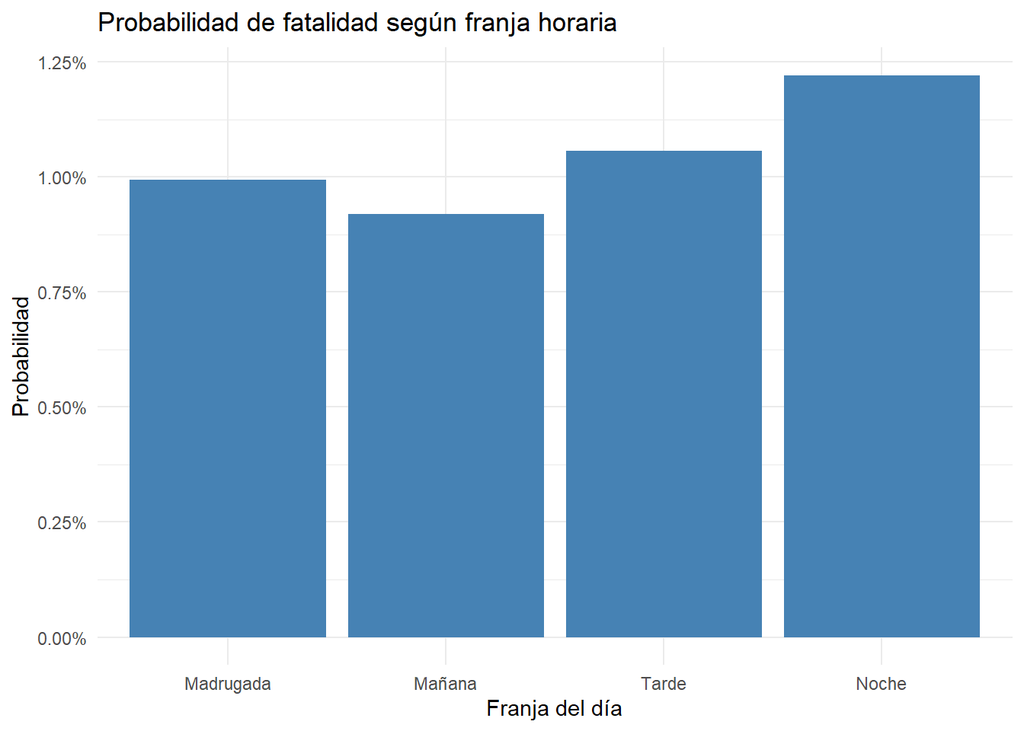

```r
# Gráfica de probabilidad horario
ggplot(prob_franja, aes(x = franja, y = probabilidad)) +
  geom_col(fill = "steelblue") +
  scale_y_continuous(labels = percent) +
  labs(
    title = "Probabilidad de fatalidad según franja horaria",
    x = "Franja del día",
    y = "Probabilidad"
  ) +
  theme_minimal()
```

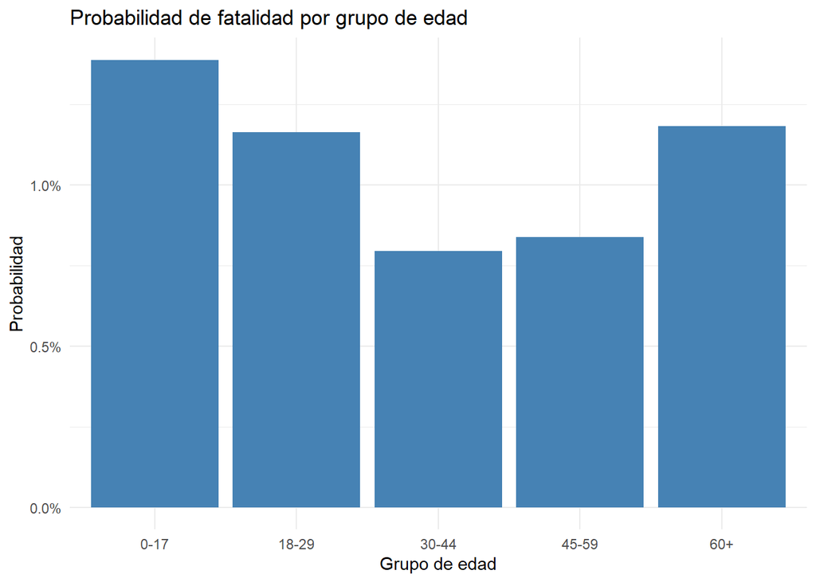

```r
# Gráfica de probabilidad por grupo de edad
ggplot(prob_edad, aes(x = grupo_edad, y = probabilidad)) +
  geom_col(fill = "steelblue") +
  scale_y_continuous(labels = percent) +
  labs(
    title = "Probabilidad de fatalidad por grupo de edad",
    x = "Grupo de edad",
    y = "Probabilidad"
  ) +
  theme_minimal()
```

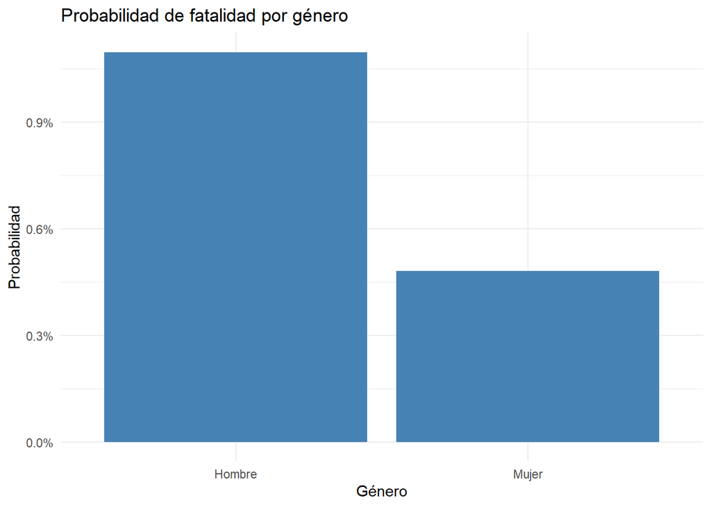

```r
# Gráfica de probabilidad por género
ggplot(prob_genero, aes(x = genero, y = probabilidad)) +
  geom_col(fill = "steelblue") +
  scale_y_continuous(labels = percent) +
  labs(
    title = "Probabilidad de fatalidad por género",
    x = "Género",
    y = "Probabilidad"
  ) +
  theme_minimal()
```

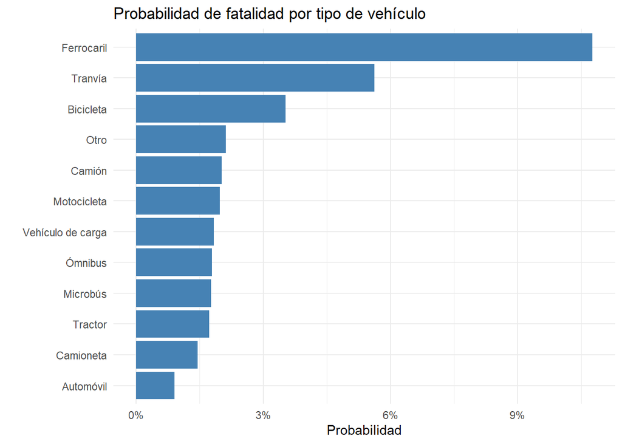

```r
# Gráfica de probabilidad por tipo de vehiculo

ggplot(prob_veh, aes(x = reorder(tipo_de_vehiculo, probabilidad), y = probabilidad)) +
geom_col(fill = "steelblue") +
coord_flip() +
scale_y_continuous(labels = percent) +
labs(title = "Probabilidad de fatalidad por tipo de vehículo",
x = "", y = "Probabilidad") +
theme_minimal()
```

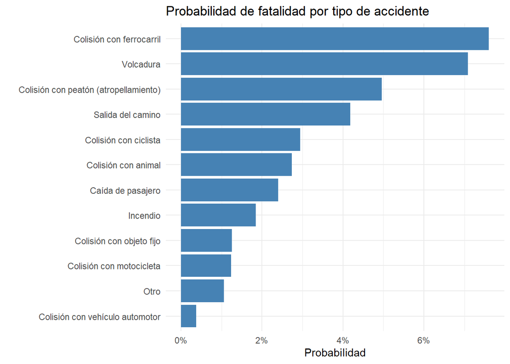

```r
# Gráfica de probabilidad por tipo de accidente
ggplot(prob_tipo, aes(x = reorder(tipo_de_accidente, probabilidad), y = probabilidad)) +
geom_col(fill = "steelblue") +
coord_flip() +
scale_y_continuous(labels = percent) +
labs(title = "Probabilidad de fatalidad por tipo de accidente",
x = "", y = "Probabilidad") +
theme_minimal()
```

## Conclusión

La fatalidad en los accidentes de tránsito está fuertemente asociada a la vulnerabilidad física de la víctima (edad, género, tipo de vehículo), la naturaleza del impacto (atropellamientos, ferrocarril, motocicletas), las condiciones del conductor (alcohol, uso del cinturón), el momento del día y las condiciones del entorno. Estos resultados no solo describen patrones de riesgo, sino que apuntan a intervenciones prioritarias en seguridad vial, infraestructura, educación y regulación.